# Hospital dataset

Vu Duc Thanh

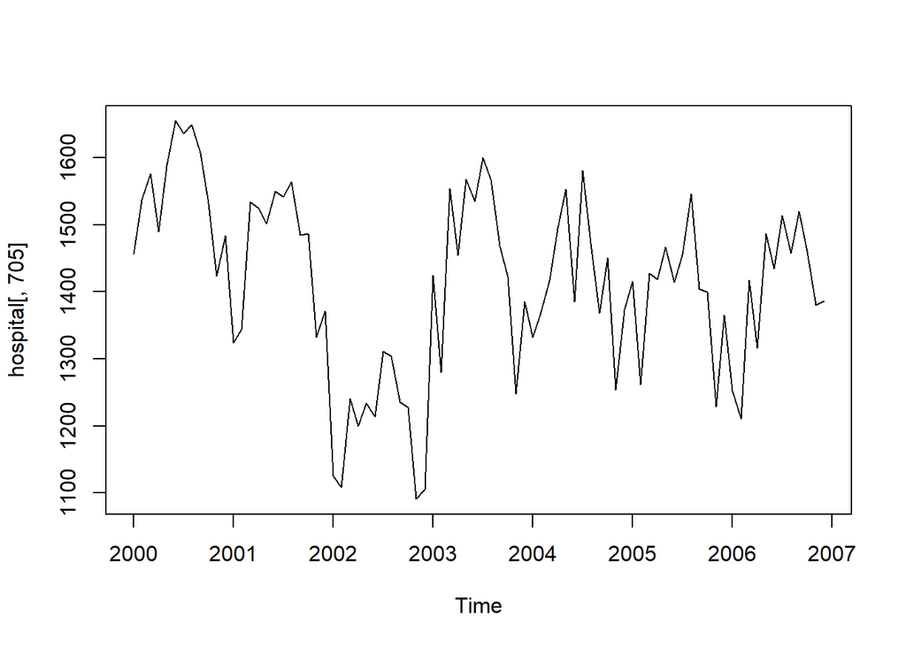

```r
library(expsmooth)
data(hospital)
plot(hospital[,705],type='l')
```

STL decomposition

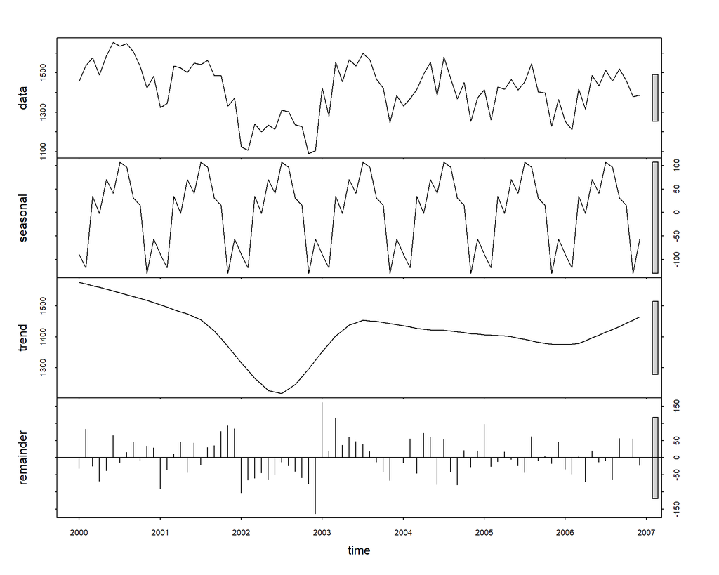

Box-Cox transformation with optimal $\lambda$:

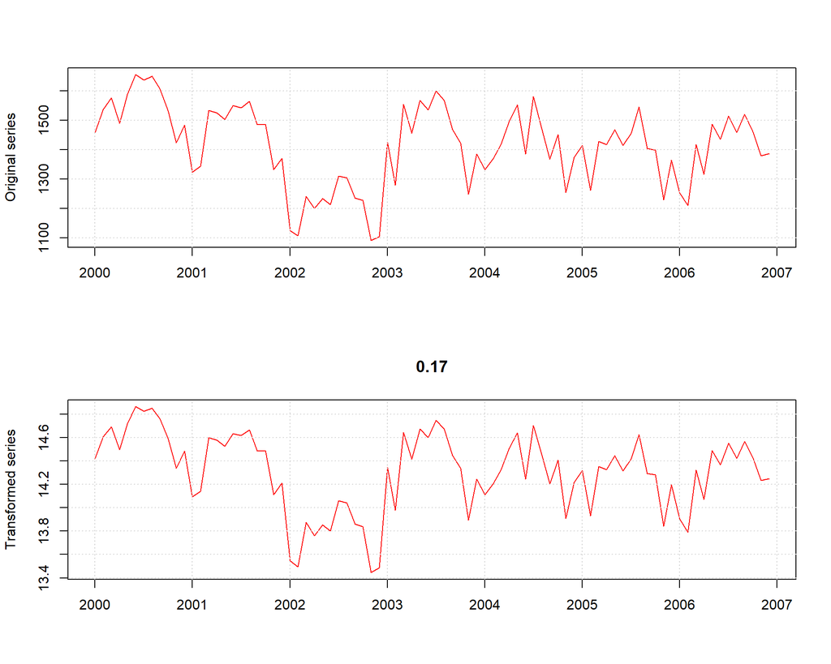

Transformation clearly stabilizes the variance, so it makes sense to use it. What if we round $\lambda$ to 0?

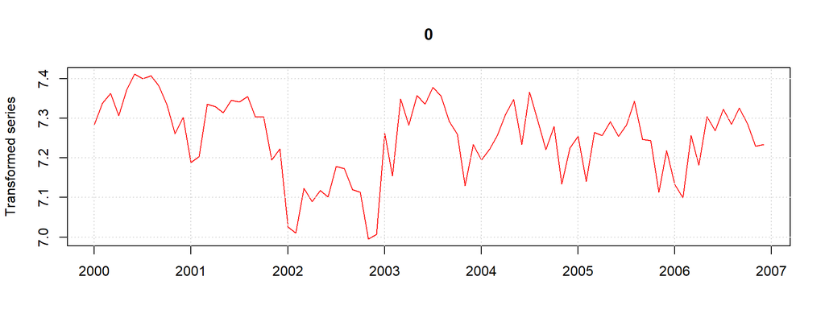

Looks the same. We’ll use $\lambda=0$ from now on.

## ARIMA

### Automatic model selection

Using auto.arima:

```
## Series: df
## ARIMA(2,0,0)(2,0,0)[12] with non-zero mean
## Box Cox transformation: lambda= 0
##
## Coefficients:
##          ar1     ar2    sar1    sar2    mean
##       0.4891  0.3417  0.2748  0.2791  7.2766
## s.e.  0.1025  0.1029  0.0996  0.1131  0.0686
##
## sigma^2 = 0.003948:  log likelihood = 113.32
## AIC=-214.64   AICc=-213.55   BIC=-200.05
```

ARIMA(2,0,0)(2,0,0)$_{12}$ is selected. Here are the residuals:

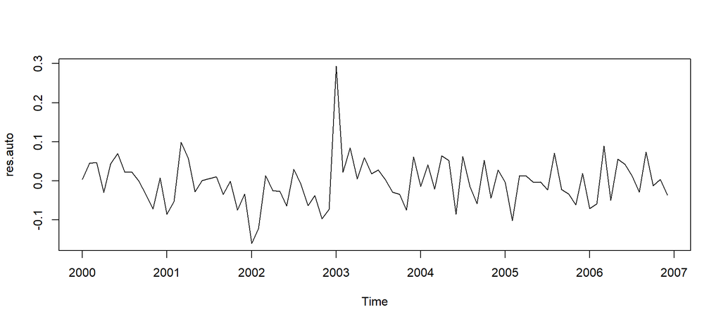

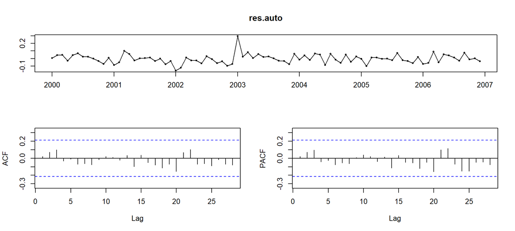

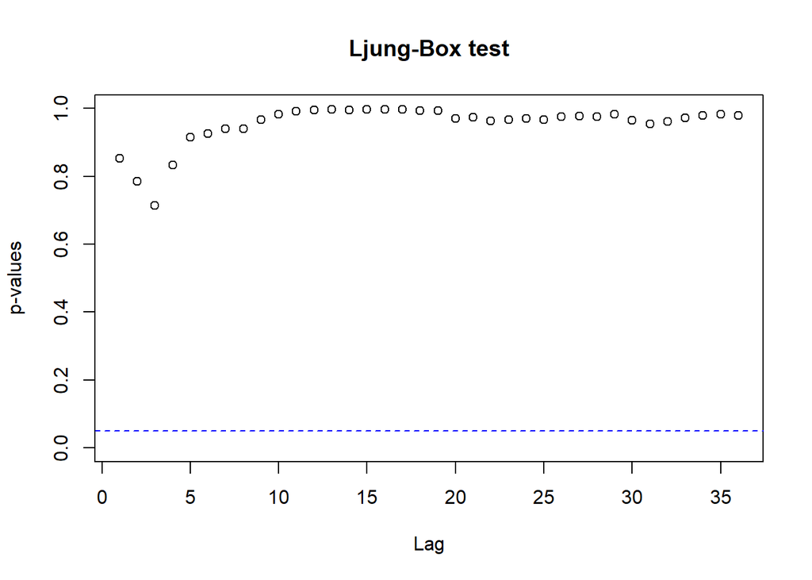

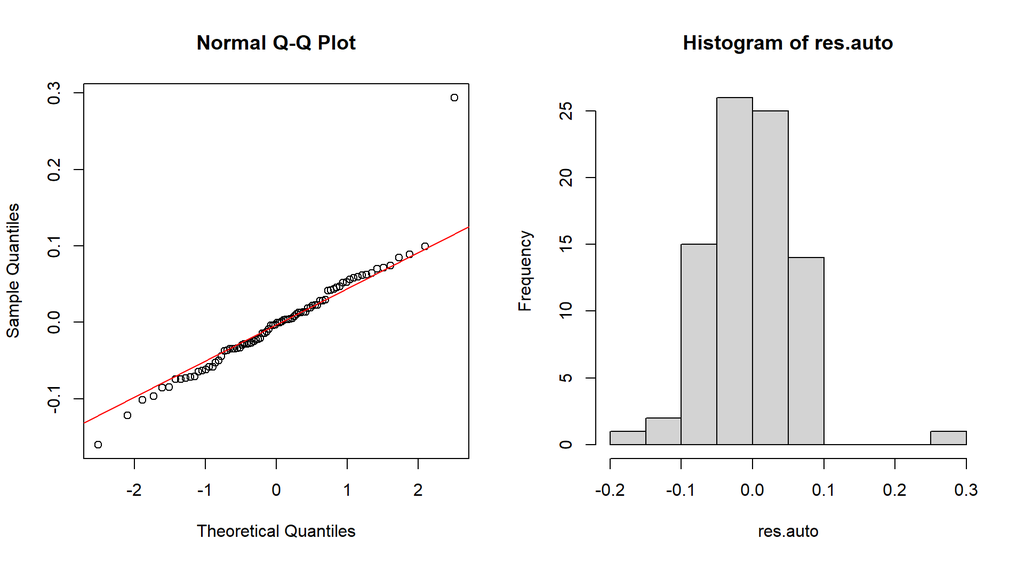

| Hypothesis | Test | Result | P-value |
| --- | --- | --- | --- |
| Normality | Shapiro-Wilk | rejected | 1.2616396^{-4} |
| Unbiasedness | Wilcoxon | not rejected | 0.4259912 |
| Stationarity | KPSS | not rejected | 0.1 |

Fitting the selected model to the first $T-D$ points of the series to check the accuracy of the forecast on the last $D$ points:

```
##                     ME     RMSE      MAE        MPE     MAPE      MASE
## Training set -2.778056 82.19764 61.03464 -0.5468209 4.438705 0.4107771
## Test set      7.085544 72.08172 59.46565  0.1833258 4.350812 0.4002175
##                   ACF1 Theil's U
## Training set 0.0195702        NA
## Test set     0.2026398 0.6629433
```

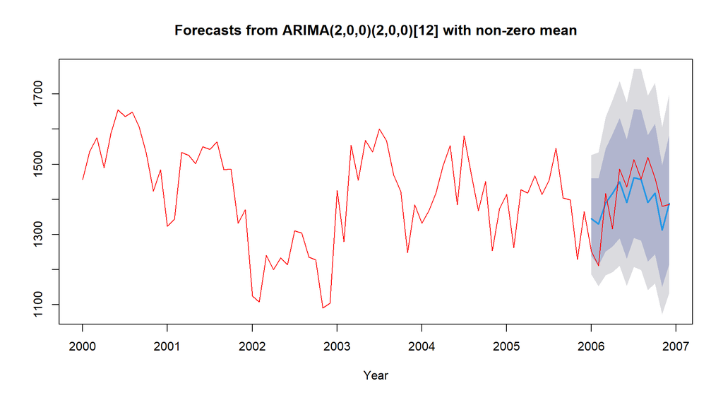

### Manual model tuning

The series is stationary (p> 0.1, KPSS test)

Look at ACF and PACF of the obtained series:

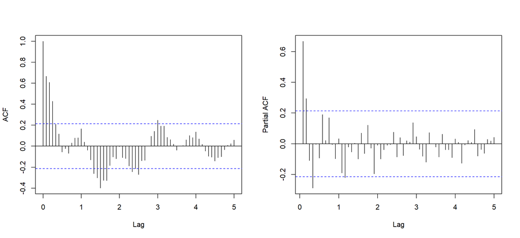

```
## Series: df
## ARIMA(2,0,0)(2,0,0)[12] with non-zero mean
## Box Cox transformation: lambda= 0
##
## Coefficients:
##          ar1     ar2    sar1    sar2    mean
##       0.4891  0.3417  0.2748  0.2791  7.2766
## s.e.  0.1025  0.1029  0.0996  0.1131  0.0686
##
## sigma^2 = 0.003948:  log likelihood = 113.32
## AIC=-214.64   AICc=-213.55   BIC=-200.05
```

## Final model selection

Comparing the residuals of two ARIMAs:

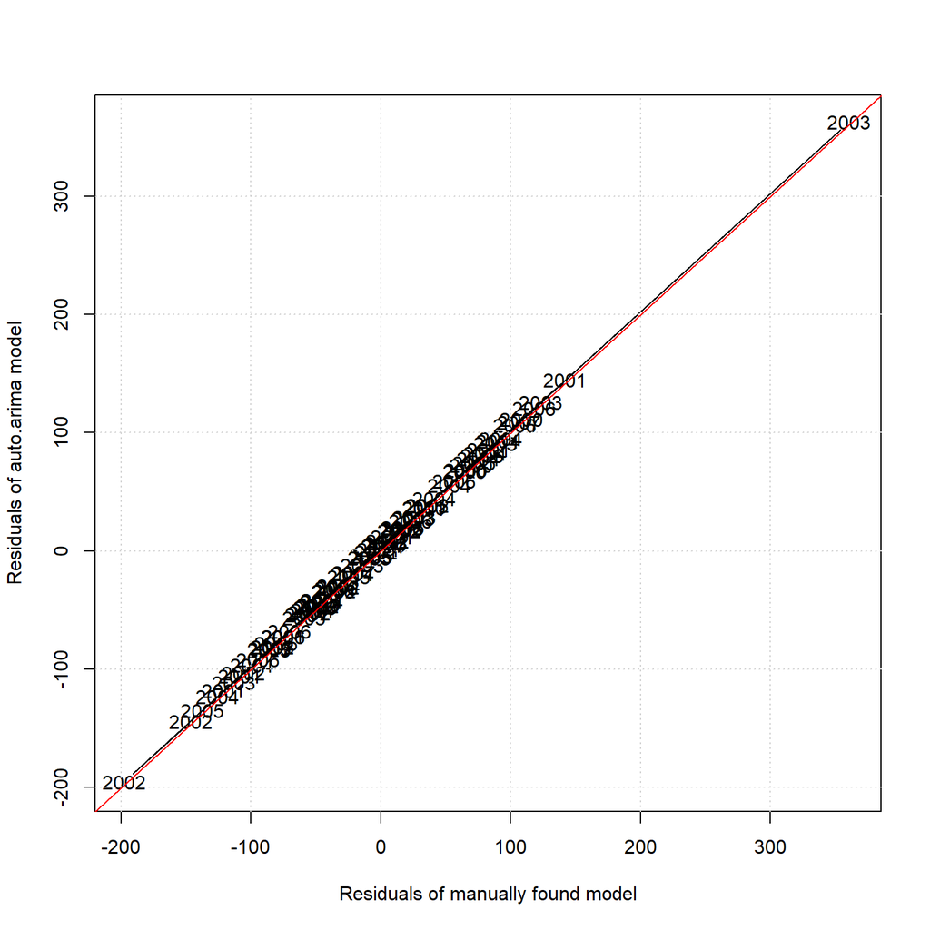

```
##
##  Diebold-Mariano Test
##
## data:  resres.auto
## DM = 0.43534, Forecast horizon = 1, Loss function power = 2, p-value =
## 0.6644
## alternative hypothesis: two.sided
```

The model now is exact the same with the auto model. Compare with ETS model

## ETS model

```
## ETS(A,A,A)
##
## Call:
##  ets(y = df, model = "AAA", lambda = LambdaOpt)
##
##   Box-Cox transformation: lambda= 0
##
##   Smoothing parameters:
##     alpha = 0.5732
##     beta  = 1e-04
##     gamma = 1e-04
##
##   Initial states:
##     l = 7.3741
##     b = -0.0017
##     s = -0.039 -0.1026 0.0124 0.0167 0.0709 0.0759
##            0.0227 0.0516 0.0077 0.0349 -0.0892 -0.0621
##
##   sigma:  0.0573
##
##       AIC      AICc       BIC
## -91.92539 -82.65267 -50.60151
```

Residuals:

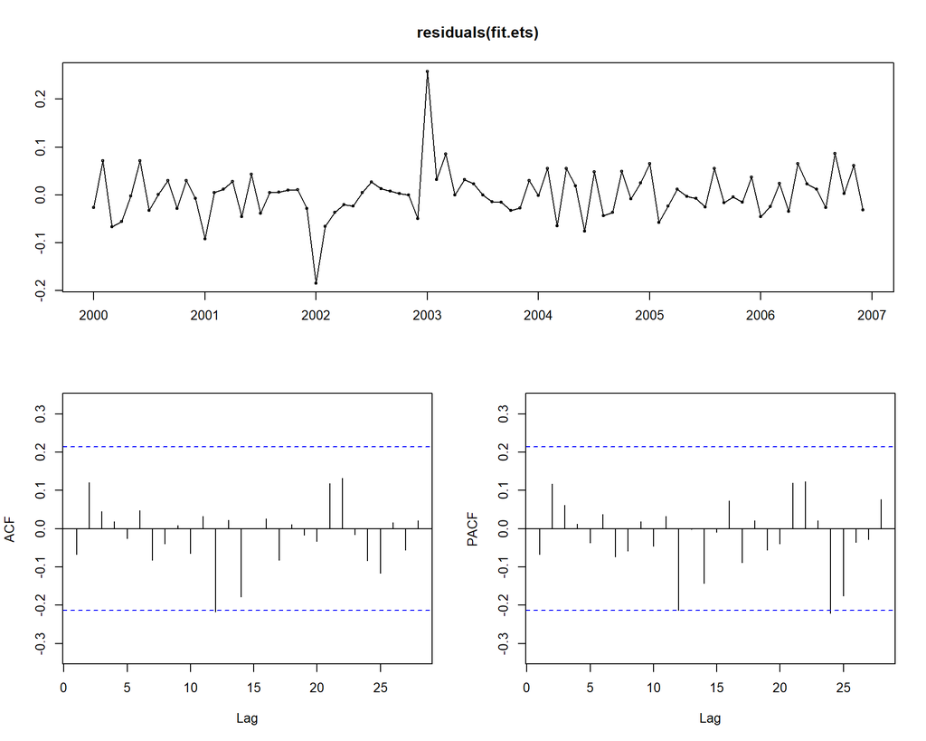

Ljung-Box test p-values for them:

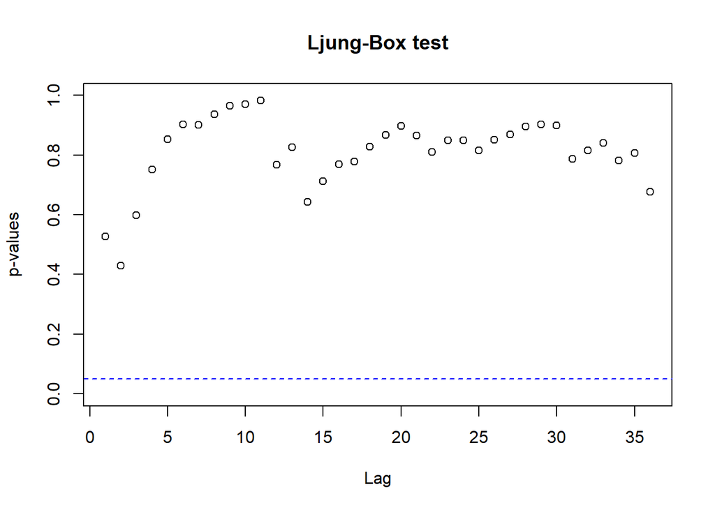

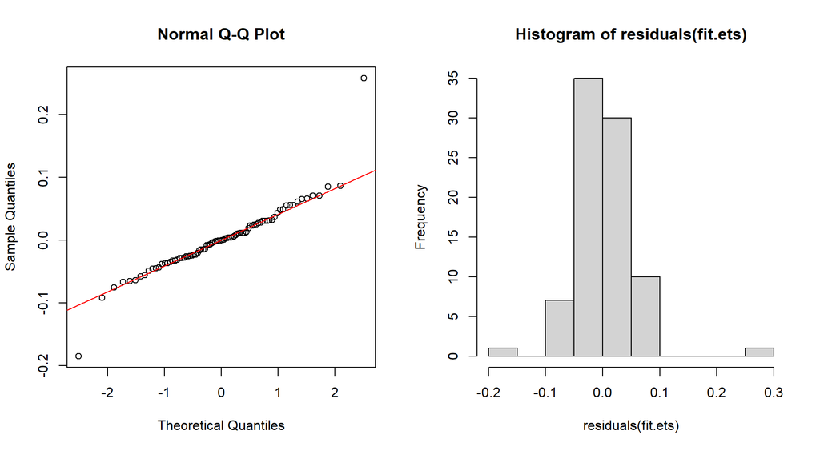

| Hypothesis | Test | Result | P-value |
| --- | --- | --- | --- |
| Normality | Shapiro-Wilk | rejected | 4.637582^{-6} |
| Unbiasedness | Wilcoxon | not rejected | 0.9342444 |
| Stationarity | KPSS | not rejected | 0.1 |

```r
shapiro.test(residuals(fit.ets))$p.value
```

```
## [1] 4.637582e-06
```

```r
wilcox.test(residuals(fit.ets))$p.value
```

```
## [1] 0.9342444
```

```r
kpss.test(residuals(fit.ets))$p.value
```

```
## [1] 0.1
```

Fitting the selected model to the first $T-D$ points of the series to check the accuracy of the forecast on the last $D$ points:

```
##                      ME     RMSE      MAE        MPE     MAPE      MASE
## Training set  0.9548921 70.80093 48.54623 -0.1003425 3.460891 0.3267273
## Test set     15.4243555 74.21197 61.95052  0.8823881 4.491259 0.4169413
##                     ACF1 Theil's U
## Training set -0.08309335        NA
## Test set      0.41222237 0.6899253
```

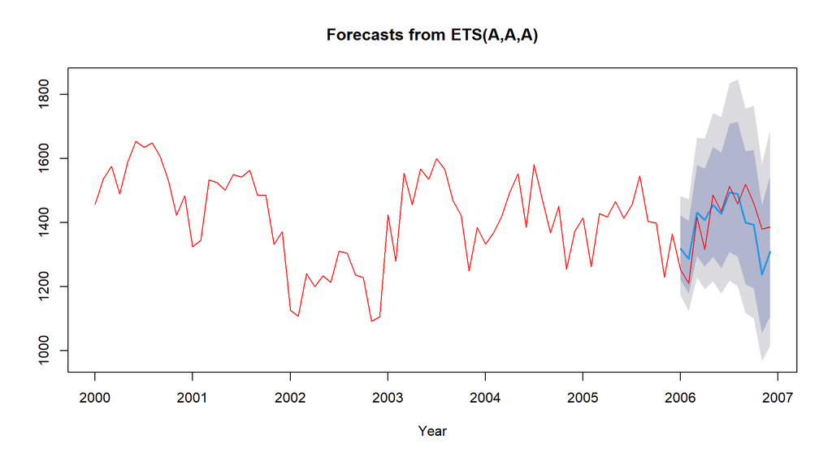

Comparing the residuals of the best ARIMA and the best ETS models:

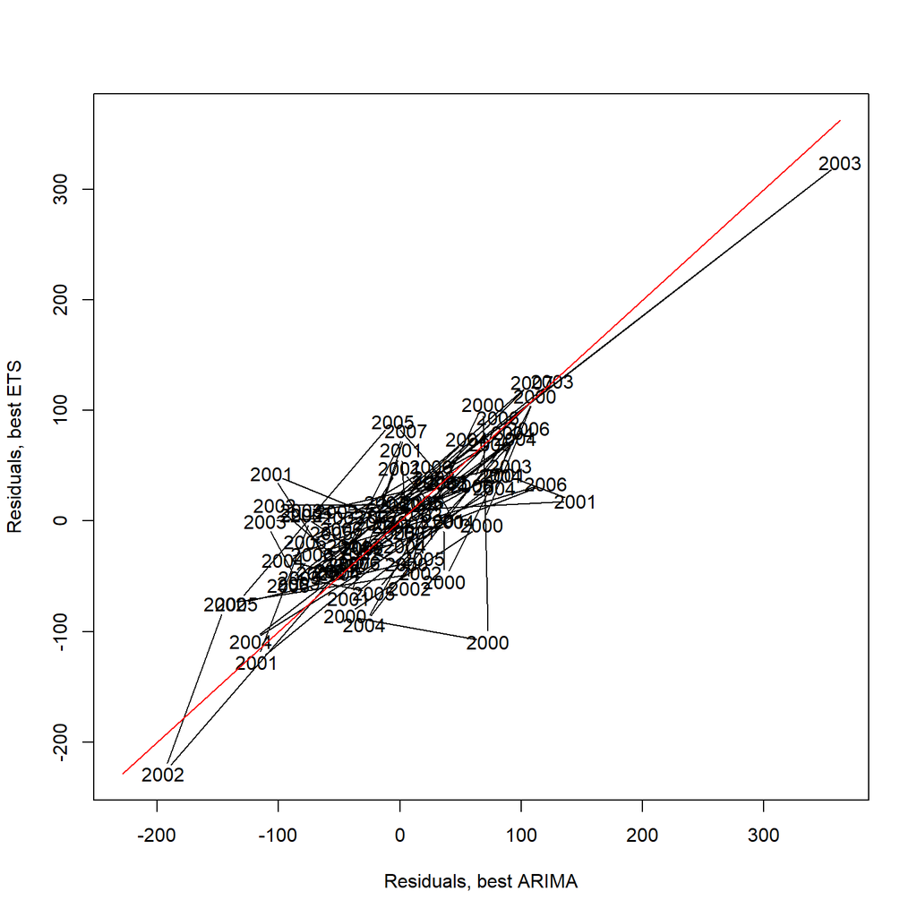

```
##
##  Diebold-Mariano Test
##
## data:  res.autores.ets
## DM = 2.595, Forecast horizon = 1, Loss function power = 2, p-value =
## 0.01118
## alternative hypothesis: two.sided
```

```
##
##  Diebold-Mariano Test
##
## data:  res.autores.ets
## DM = 2.595, Forecast horizon = 1, Loss function power = 2, p-value =
## 0.005591
## alternative hypothesis: greater
```

Diebold-Mariano test says ETS is better.

## Forecast

The residuals of the model are not normal, so we use bootstrap for prediction intervals:

```
##          Point Forecast    Lo 80    Hi 80    Lo 95    Hi 95
## Jan 2006       1318.709 1252.005 1387.374 1195.372 1452.227
## Feb 2006       1286.968 1207.611 1370.554 1153.669 1476.076
## Mar 2006       1431.215 1330.888 1540.273 1258.428 1682.339
## Apr 2006       1407.663 1294.052 1529.836 1221.172 1683.427
## May 2006       1455.177 1326.557 1596.391 1241.677 1748.762
## Jun 2006       1427.563 1292.324 1576.908 1208.690 1728.178
## Jul 2006       1494.898 1348.215 1672.979 1257.338 1836.747
## Aug 2006       1489.603 1328.841 1678.572 1230.750 1848.221
## Sep 2006       1400.623 1241.552 1586.727 1150.336 1750.384
## Oct 2006       1393.960 1228.150 1589.339 1134.049 1755.742
## Nov 2006       1237.587 1083.487 1421.271 1000.609 1567.061
## Dec 2006       1308.944 1137.634 1509.385 1045.403 1684.848
```

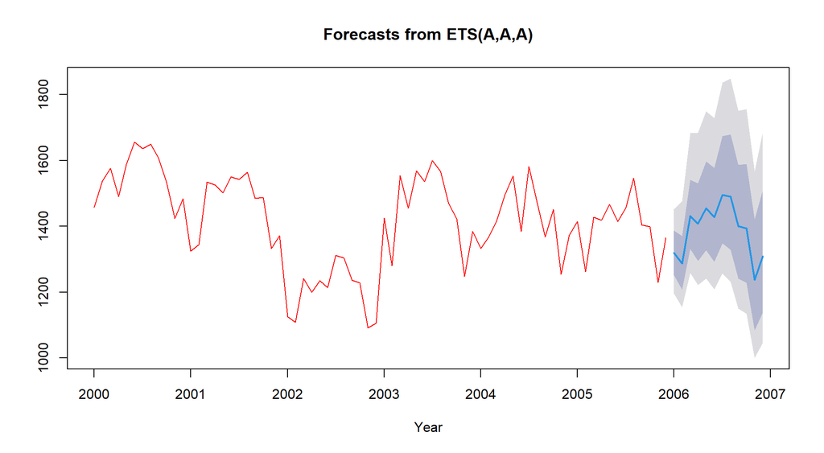